# Assignments

# Grading Overview

# In-class Work and Exercises (15%)

## Assignment Overview

- Includes written reflections, quizzes, and/or group work
- Students will sometimes work individually and sometimes with classmates
- Due during most class periods

## The Nitty Gritty

This course relies on active, engaged participation in class activities and discussions. There will be few lectures. You should come to every class having read all of the required texts (or watched the required videos, played the required games, &c.) and prepared to discuss them with your colleagues. I plan to assess your reading and course engagement through writing exercises, reading quizzes, and group work. Assuming you all seem to be reading with engagement, I will usually ask for in-class writing or group exercises, but I reserve the right to quiz if reading seems to be slipping.

### In-class writing

You should be prepared to write in any class session and have appropriate materials (e.g. paper, a table, a laptop) available to you. Not all in-class writing will be collected, but when it is such work will be graded on a five-point scale. I do not expect your responses to in-class writing exercises to reflect the same polish as papers. I do expect your writing exercises to reflect real thought about our course topics and readings. Entries will receive full credit if:

- They refer to specific aspects of our assigned reading. The more specific you can be, the better. For instance, if you can quote or paraphrase from a course text to illustrate the point you hope to make, you should do so.
- They draw connections between the day’s assigned reading and the broader themes of the course, recent topics of class discussion, or your personal research.
- They demonstrate depth of thought about the topics on hand.
- Writing that demonstrates a firm command of the day’s reading through summarizing its ideas will receive a 4/5 while writing that *connects ideas across readings* and *ventures creative (or even risky) interpretations* will receive 5/5. Lower marks are reserved for writing that does not demonstrate familiarity with the day’s readings, fails to address the prompt, and/or lacks clarity.

### Individual and Group Work

In addition to discussion of course texts, our classes will frequently ask you to complete small projects and exercises that will help you apply course concepts, learn new software, and/or contextualize course materials. For group exercises, I will ask each group member to assume a specific task related to the project; I expect each group member to contribute in significant ways to their team’s effort. The outcome of group work will be various and thus will be assessed in diverse ways.

### Reading quizzes

I would prefer not to resort to reading quizzes, which test basic comprehension rather than synthesis and analysis. However, if it becomes clear that significant portions of the class are not completing the readings (which will be obvious by the resultant lulls in conversation) then I will turn to quizzes to motivate closer attention to the readings. Reading quizzes are intended to reward careful reading, not to test your recall of obscure facts from our texts. If you read the assigned texts attentively—*if you read the assigned texts attentively*—you should do well on the quizzes. Each quiz will have six questions; if you correctly answer five of them you will receive full credit, while all six garners extra credit.

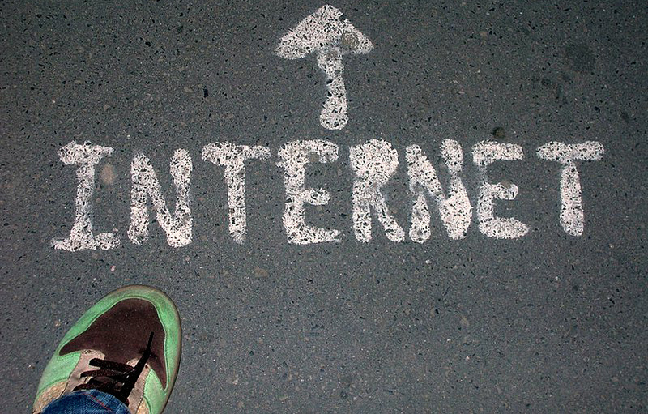

*[“Internet” by The-Samizdat](https://flic.kr/p/dcCpNJ)*

# A Domain of Your Own (5%)

## Assignment Overview

- Requires students to secure a domain and server space, install web software, and customize their sites
- Students will work individually, though they can help each other if they encounter rough patches
- Due in two stages: steps 1-5 by Friday, September 15 and steps 6-8 by Friday, September 28
- Must be completed in order to finish many other assignments, particularly the blog

This assignment was adapted (barely) from [the sterling model developed by Brian Croxall](http://www.briancroxall.net/s14dh/assignments/building-your-own-website/).

## The Nitty Gritty

1. Purchase a domain from www.reclaimhosting.com and **send me an email letting me know your domain name**. You are not required to use your own name in the domain; there are certainly arguments to be made for anonymity. If you think you might turn this domain into a professional site in the future, however, consider domain names that will convey the right image. *Note: if you already use another host, or if you prefer to start using another one for this assignment, let me know. I won’t require you to use Reclaim Hosting to complete this assignment successfully. I strongly recommend Reclaim because they grew from the [Domain of One’s Own](https://www.wired.com/insights/2012/07/a-domain-of-ones-own/) iniative from the University of Mary Washington, they support academic users phenomenally, they offer the cheapest hosting and domain service I know for students, and their customer support is phenomenal.*
2. [Install WordPress](http://portal.reclaimhosting.com/knowledgebase.php?action=displayarticle&id=2) on your domain.
3. Choose a new theme to [install on your site](https://www.youtube.com/watch?v=AL6K_pYdvfU) and activate it.
4. Install Akismet [as a plugin](https://www.youtube.com/watch?v=u075nwYCIfQ). [Get an API key](http://akismet.com/) and activate it.
5. Post first blog entry for the blogging assignment **by Friday, September 15 at 5pm**. Email me your domain, the name of the theme you installed, and, a screenshot of Akismet active on your site by this deadline.
6. Create an “About” page. On that page write a brief paragraph or two about yourself that includes the following information: a brief paragraph about yourself. You might discuss what you’re studying (generally) in school and what your educational or career goals are, or you might choose to describe some other aspect of yourself. You do not have to name yourself here, either—personae are allowed.
7. Create one other static page about *something*. It could be where you post an assignment you do for class. It could be about a hobby.
8. Find one thing that you wish your website could do. Find a [plugin](http://wordpress.org/plugins/) to do it. Install that plugin **by Friday, September 28**. Email me with links to your two pages and the name of the plugin you installed.

## An Alternative

Maybe you’ve built a website before. Maybe Wordpress is old hat for you. There are lots of other ways to build a website. Recently flat HTML platforms [like Jekyll](https://jekyllrb.com/) have been getting lots of buzz: they load quick and don’t have all the overhead of a database-driven platform like Wordpress. Once the system is set up they’re remarkably easy to use, but the setup is more complicated than WP. If you’d like to challenge yourself in this assignment, consider building a Jekyll site, [perhaps hosted through Github](https://help.github.com/articles/using-jekyll-as-a-static-site-generator-with-github-pages/). If you’d like to go this route, come chat with me and we’ll lay out the options and necessities.

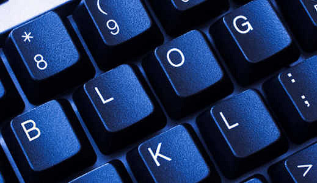

*[“Blogging” by Daryl Lau](https://flic.kr/p/9NKZgU)*

# Blogging (25%)

## Assignment Overview

- Students will work throughout the semester developing ideas in writing
- 10 weekly posts are due through the semester, each week’s by Friday at 5pm

## Rationale

Throughout the term, we will engage with the ideas of the course through public writing on your blogs, which I will aggregate on this course blog. I ask you to blog for a number of reasons:

- All writing—even academic writing—is being reshaped by online modes of publication. Many academics maintain personal research blogs in which they try out their ideas and get feedback before developing articles or even books. Outside of academia, public, online writing plays an increasing and essential role in many fields. I believe its essential for modern college students to develop skill crafting an online writing persona and I want to foster that development.
- In a related point, blogs give you the opportunity to experiment with your writing, composing arguments that integrate links, quotations, images, video, and other online media as evidence.
- Blogging allows for a broader spectrum of participation in the class. Even shy students can contribute to a course blog.
- Blog posts give you the chance to learn from each other. You’ll read your colleague’s writing and, hopefully, learn from it or be challenged by it.
- Public blogging allows us to connect to larger communities outside of our classroom. Who knows? Perhaps the author of an article you blog about will respond directly…

You should not treat blog posts like a secondary assignment. Indeed, I consider your blog post the central assignment of the semester. Instead, *think of your blog posts as an evolving research paper*. They have the same importance and weight and seriousness.

## The Nitty-Gritty

Each post must begin from our course readings and demonstrate your further engagement with those readings. In general, then, your blog posts should:

1. There are approximately 14 weeks in our semester and *you are responsible for writing 10 blog posts*. You may not submit (for credit) more than one blog post per week, though you’re free to write more if you wish. I cannot emphasis more strongly that **you should not wait to start writing posts**. Let me repeat that: **do not wait until week 3 or 4 to begin writing your blog assignments**. I assign 10 posts to give you some flexibility during the semester. It is up to you to make that flexibility a boon rather than a bane.
2. Blog posts for a given week are due by Friday at 5pm. Anything submitted later than this will count toward the next week, and I do not give credit for more than one post submitted per week.
3. Each post must be 300-500 words long. This gives you enough space to make some keen observations or ask some pressing questions, but not enough space to write a full paper. Your blog posts should be concise. The point is not to write everything you might in one week, but instead to develop a set of ideas and questions over the course of many weeks.
4. Each post must *refer specifically to class reading*, often through *direct quotation*. Your posts should continue and further develop conversations that began in class, demonstrating your evolving understanding of our class themes. I strongly encourage you to read, cite, and link to each other’s posts.
5. I highly value posts that link our class to the wider world. I encourage you to use your blog posts to bring outside texts into conversation with our class: an article you found interesting or relevant, say, or something you uncovered while doing research.

## Commenting on Posts

I cannot comment on every blog post, though I will occasionally interject when something in a post catches our attention. You should interpret such a comment as engagement, not (necessarily) sanction. Conversely, you should not interpret lack of comment as criticism.

## Grading Blog Posts

Each week I will review and grade blog posts according to the following rubric, adapted by Creative Commons license (CC BY 3.0) from [Mark Sample](http://www.samplereality.com/2009/08/14/pedagogy-and-the-class-blog/).

[output not shown]